# Assignment 9

Suzanne Combs

December 2, 2024

*The codes are included, but hidden. To view the code click the “show” button  
For assignment 9, my task is to:

- Use the data set “/Data/GradSchool_Admissions.csv”
- Explore and model the predictors of graduate school admission
- Document data explorations, figures, and conclusions in a reproducible R-markdown report

I’ll first load the data set.

```r
## Use the data set "/Data/GradSchool_Admissions.csv" ####
# Load in the dataset
df <- read_csv("../../Data/GradSchool_Admissions.csv")
```

Then clean it up. To clean the data set, I will change “admit” to a logical because it can either be true or false. I will also change “rank” to a factor since there are only 4 different level options.

```r
# Clean the dataset. Changing the variable types
df$admit <- as.logical(df$admit)
df$rank <- as.factor(df$rank)
```

Next, I will explore the data

```r
glimpse(df)
```

```
## Rows: 400
## Columns: 4
## $ admit <lgl> FALSE, TRUE, TRUE, TRUE, FALSE, TRUE, TRUE, FALSE, TRUE, FALSE, …
## $ gre   <dbl> 380, 660, 800, 640, 520, 760, 560, 400, 540, 700, 800, 440, 760,…
## $ gpa   <dbl> 3.61, 3.67, 4.00, 3.19, 2.93, 3.00, 2.98, 3.08, 3.39, 3.92, 4.00…
## $ rank  <fct> 3, 3, 1, 4, 4, 2, 1, 2, 3, 2, 4, 1, 1, 2, 1, 3, 4, 3, 2, 1, 3, 2…
```

and view different plots using ggpairs for a quick look

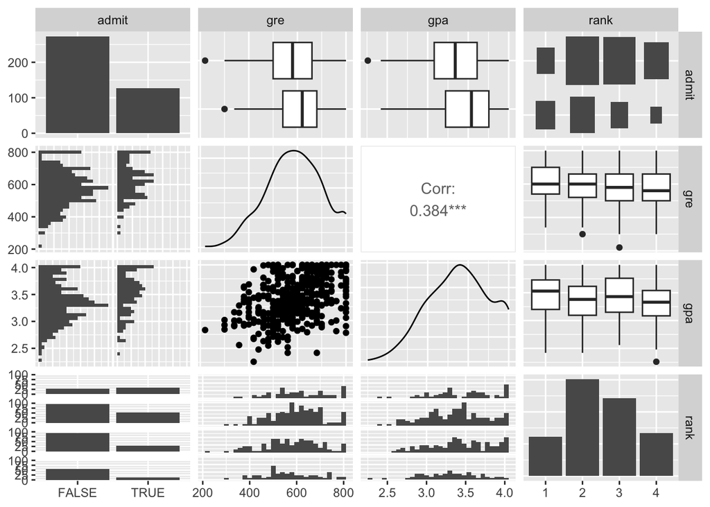

```r
ggpairs(df)
```

There seems to be differences between the chance of being admitted between schools of different ranks. This is one of the things I will look at more in my visualization.

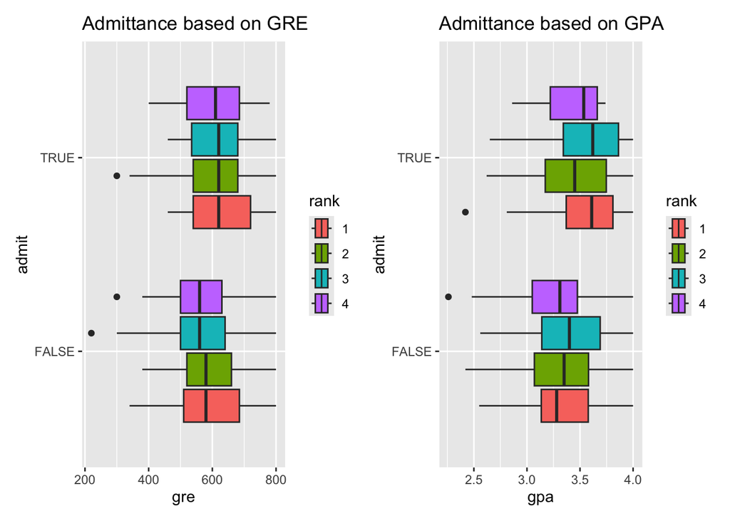

```r
# Boxplots
p1 <- ggplot(df, aes(y=admit, x=gre, fill=rank)) +
  geom_boxplot() +
    labs(title = "Admittance based on GRE")

p2 <- ggplot(df, aes(y=admit, x=gpa, fill=rank)) +
  geom_boxplot() +
  labs(title = "Admittance based on GPA")

# Jitter Scatterplots
p3 <- ggplot(df, aes(y=admit, x=gre, color=rank)) +
  geom_jitter() +
  theme_minimal() +
  labs(title = "Admittance based on gre")

p4 <- ggplot(df, aes(y=admit, x=gpa, color=rank)) +
  geom_jitter() +
  theme_minimal() +
  labs(title = "Admittance based on gpa")
p1 + p2
```

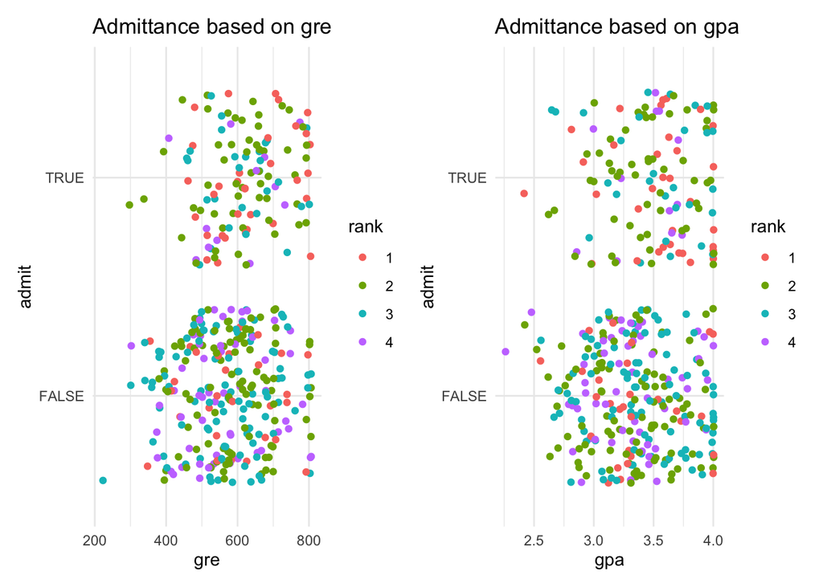

```r
p3 + p4
```

It is difficult to tell if rank, gre, and gpa effects admittance rates based on these plots. I am going to create three different models to see what is significant.

Model 1

```r
# Models
mod1 <- glm(data=df, formula = admit ~ gpa:gre + rank, family = "binomial")
summary(mod1)
```

```
##
## Call:
## glm(formula = admit ~ gpa:gre + rank, family = "binomial", data = df)
##
## Coefficients:
##               Estimate Std. Error z value Pr(>|z|)
## (Intercept) -1.6234387  0.5463047  -2.972 0.002962 **
## rank2       -0.6816226  0.3153411  -2.162 0.030654 *
## rank3       -1.3174841  0.3431381  -3.840 0.000123 ***
## rank4       -1.5545338  0.4171993  -3.726 0.000194 ***
## gpa:gre      0.0008424  0.0002266   3.718 0.000201 ***
## ---
## Signif. codes:  0 '***' 0.001 '**' 0.01 '*' 0.05 '.' 0.1 ' ' 1
##
## (Dispersion parameter for binomial family taken to be 1)
##
##     Null deviance: 499.98  on 399  degrees of freedom
## Residual deviance: 460.48  on 395  degrees of freedom
## AIC: 470.48
##
## Number of Fisher Scoring iterations: 4
```

From this model, the interaction between gpa and gre appear to be significant. Rank also seems to be significant, although rank2 is less significant than the other ranks.  
Model 2

```r
mod2 <- glm(data=df, formula = admit ~ gpa + gre + rank, family = "binomial")
summary(mod2)
```

```
##
## Call:
## glm(formula = admit ~ gpa + gre + rank, family = "binomial",
##     data = df)
##
## Coefficients:
##              Estimate Std. Error z value Pr(>|z|)
## (Intercept) -3.989979   1.139951  -3.500 0.000465 ***
## gpa          0.804038   0.331819   2.423 0.015388 *
## gre          0.002264   0.001094   2.070 0.038465 *
## rank2       -0.675443   0.316490  -2.134 0.032829 *
## rank3       -1.340204   0.345306  -3.881 0.000104 ***
## rank4       -1.551464   0.417832  -3.713 0.000205 ***
## ---
## Signif. codes:  0 '***' 0.001 '**' 0.01 '*' 0.05 '.' 0.1 ' ' 1
##
## (Dispersion parameter for binomial family taken to be 1)
##
##     Null deviance: 499.98  on 399  degrees of freedom
## Residual deviance: 458.52  on 394  degrees of freedom
## AIC: 470.52
##
## Number of Fisher Scoring iterations: 4
```

This model, rank3 and rank4 are significant and gpa, gre, and rank2 are less significant.  
Model 3

```r
mod3 <- glm(data=df, formula = admit ~ gpa * gre * rank, family = "binomial")
summary(mod3)
```

```
##
## Call:
## glm(formula = admit ~ gpa * gre * rank, family = "binomial",
##     data = df)
##
## Coefficients:
##                 Estimate Std. Error z value Pr(>|z|)
## (Intercept)   -35.999967  16.048971  -2.243   0.0249 *
## gpa            10.242737   4.716620   2.172   0.0299 *
## gre             0.052274   0.025176   2.076   0.0379 *
## rank2          33.954685  18.430800   1.842   0.0654 .
## rank3          14.608867  20.838126   0.701   0.4833
## rank4          13.935601  24.587935   0.567   0.5709
## gpa:gre        -0.014640   0.007294  -2.007   0.0447 *
## gpa:rank2     -10.105436   5.447632  -1.855   0.0636 .
## gpa:rank3      -4.978875   6.062873  -0.821   0.4115
## gpa:rank4      -4.666198   7.120462  -0.655   0.5123
## gre:rank2      -0.054299   0.029213  -1.859   0.0631 .
## gre:rank3      -0.020111   0.033741  -0.596   0.5511
## gre:rank4      -0.023092   0.040135  -0.575   0.5651
## gpa:gre:rank2   0.015725   0.008524   1.845   0.0651 .
## gpa:gre:rank3   0.006381   0.009675   0.659   0.5096
## gpa:gre:rank4   0.006888   0.011536   0.597   0.5505
## ---
## Signif. codes:  0 '***' 0.001 '**' 0.01 '*' 0.05 '.' 0.1 ' ' 1
##
## (Dispersion parameter for binomial family taken to be 1)
##
##     Null deviance: 499.98  on 399  degrees of freedom
## Residual deviance: 450.39  on 384  degrees of freedom
## AIC: 482.39
##
## Number of Fisher Scoring iterations: 5
```

This model only shows to be slightly significant for some of the variables.  
Now that I have created 3 models, I can compare the models to see which would work best.  
Comparing performance

```r
# Models
# Compare the performance
comps <- compare_performance(mod1, mod2, mod3, rank=TRUE)
```

```
## Following indices with missing values are not used for ranking: Sigma
```

```r
comps
```

```
## # Comparison of Model Performance Indices
##
## Name | Model | Tjur's R2 |  RMSE | Sigma | Log_loss | Score_log | Score_spherical |   PCP | AIC weights | AICc weights | BIC weights | Performance-Score
## --------------------------------------------------------------------------------------------------------------------------------------------------------
## mod1 |   glm |     0.097 | 0.442 | 1.000 |    0.576 |   -50.618 |           0.005 | 0.609 |       0.504 |        0.512 |       0.882 |            66.67%
## mod2 |   glm |     0.102 | 0.441 | 1.000 |    0.573 |   -50.755 |           0.004 | 0.611 |       0.495 |        0.487 |       0.118 |            49.60%
## mod3 |   glm |     0.117 | 0.438 | 1.000 |    0.563 |   -51.599 |           0.005 | 0.617 |       0.001 |     7.06e-04 |    6.70e-13 |            42.19%
```

Plot the comparisons

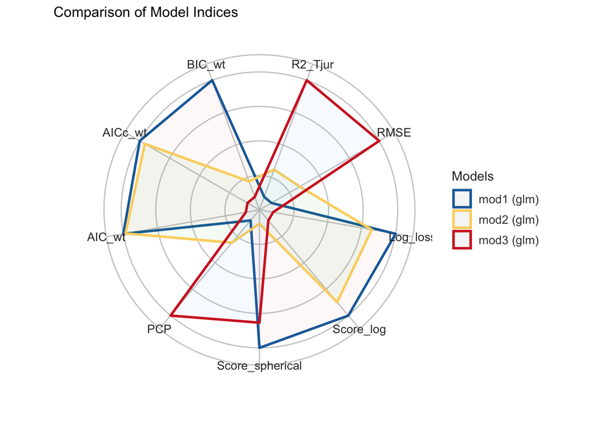

```r
# Plot the comparisons
comps %>%
  plot()
```

And look at the mean-squared-error for each model

Model 1:

```r
# Mean Residuals (Look for exact name from other assignment)
mean(mod1$residuals^2)
```

```
## [1] 5.33915
```

Model 2:

```r
mean(mod2$residuals^2)
```

```
## [1] 5.419835
```

Model 3:

```r
mean(mod3$residuals^2)
```

```
## [1] 5.330803
```

The mean residuals were very similar for model 1 and model 3, but model 1 is a less complicated model than model 3.  
I will add predictions from mod1 to a new dataframe

```r
# Add predictions from mod1 to a new dataframe
df2 <- add_predictions(df, mod1, type="response")
```

and create plots comparing gre and gpa on admittance

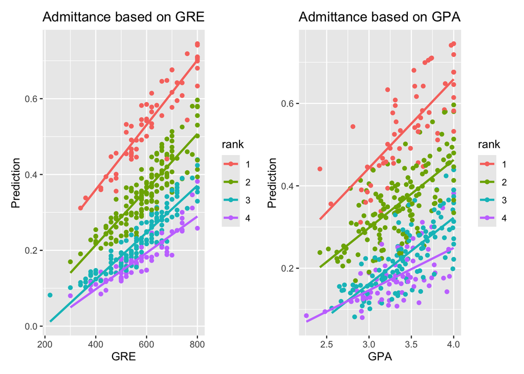

```r
# Predict with model 1 how gre effects admittance
p1 <- ggplot(df2, aes(x=gre, y=pred, color=rank)) + # As gre goes up, the probability goes up
  geom_point() +
  geom_smooth(se=FALSE, method="lm") +
  labs(title="Admittance based on GRE",
       x="GRE",
       y="Prediction")

# Predict with model 1 how gpa effects admittance
p2 <- ggplot(df2, aes(x=gpa, y=pred, color=rank)) + # As gpa goes up, the probability goes up
  geom_point() +
  geom_smooth(se=FALSE, method="lm") +
  labs(title="Admittance based on GPA",
       x="GPA",
       y="Prediction")

p1 + p2
```

From these predictions, it looks like the higher your GRE and GPA the more likely it is to be admitted. Also having a rank 1 school gives you the best chance to be admitted.